# Streaming Data Lake: Spark vs Flink into Apache Iceberg

*A reproducible, open-source benchmark of Apache Spark 4.1 and Apache Flink 2.2 streaming a 100,000-records/second stream into Apache Iceberg — first on a laptop with Docker, then at scale on Amazon EKS with S3 and Glue. Same jobs, same methodology, same numbers at both scales.*

Repo: **`github.com/fmorillo7694/spark-flink-iceberg`** — `docker compose up` for local, five numbered scripts for EKS. Every number below is regenerated by the scripts in the repo; nothing here is hand-typed.

## The question, and why the usual benchmark answers the wrong one

There's no shortage of "Spark vs Flink" shootouts. Almost all of them pipe Kafka → transform → Kafka and measure per-record latency. That's a real workload, but it isn't the one most teams are building right now. The workload *everyone* is building is **streaming ingestion into a lakehouse table**: Kafka → engine → **Iceberg**.

That workload behaves differently because of one fact:

> **An Iceberg sink only makes data visible at a commit boundary.** Every commit writes data files, a manifest, a new snapshot, and a catalog pointer swap. Nothing is queryable between commits.

This reframes the whole comparison:

1. **Latency is dominated by the commit interval, not the engine's record path.** Flink's sub-millisecond operator chaining and Spark's continuous/real-time modes both collapse to "you see data when the table commits." Sub-second engine latency is invisible behind a 60-second commit.
2. **The real differences move elsewhere**: at a fixed resource budget and a fixed input rate, *does the engine keep up or fall behind?* What does it cost in CPU and memory to keep up? How healthy are the files it writes? And how do the connector's upsert paths behave?

So the headline metric here is **keep-up under a fixed resource envelope**: we pin both engines to identical cores, memory, parallelism, partitions, and commit interval, point a fixed-rate firehose at them, and watch the Kafka backlog.

> **A note on Spark "Real-Time Mode."** RTM (`Trigger.RealTime`) is a Databricks Runtime feature, not part of open-source Apache Spark 4.1. And its advantage — long-running tasks that emit continuously — is exactly what an Iceberg *table* sink cannot exploit, because commits are periodic by construction. For a lakehouse sink the latency floor is the commit interval regardless of trigger, so we benchmark Spark Structured Streaming in micro-batch with a tight trigger: the honest open-source apples-to-apples path.

## How we measure "keeping up" honestly

Two measurement traps burned earlier drafts of this benchmark, and both are worth calling out because they're easy to fall into:

**Trap 1 — measuring consumed offsets instead of committed data.** Kafka consumer lag or a Spark "planned offset" tells you what the engine has *read*, not what it has *durably written to the table*. Those differ by a whole commit's worth of buffered data, and the two engines buffer differently — so comparing them flatters whoever buffers more. **We measure the engine's own output instead:** the Iceberg snapshot's `total-records`. Backlog is then simply

```
lag = kafka_produced_offset − iceberg_snapshot_total_records
```

Both numbers are absolute counts from zero on a freshly created table and topic, so it's genuinely apples-to-apples, engine-agnostic, and immune to how each engine buffers or how often it commits. File sizes come from the same place — the snapshot summary's `total-data-files` / `total-files-size` — so orphaned files from a previous run can never contaminate the count.

**Trap 2 — reading the sawtooth wrong.** With batch commits, backlog is a sawtooth: it climbs for 60 seconds, then a commit lands and it drops. The lowest point of each cycle — the backlog *right after* a commit — is the honest baseline. If those post-commit floors are flat or shrinking, the engine keeps up. If they climb, it's falling behind. Fitting a line through *all* samples (including the warmup ramp and the intra-cycle climb) is wrong and will tell you a keeping-up engine is failing.

> With 60-second commits, "lag = 0" is not achievable and not the goal — the floor is always about one commit of data. **Flat floor = keeping up. Rising floor = falling behind.** That's the verdict we report.

## The setup

Identical jobs run in both environments; only the bindings change.

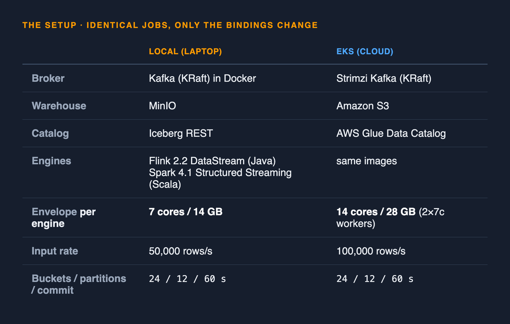

The envelope and rate scale ~2:1 between local and cloud; **the ratios, bucketing, and commit interval are identical**, which is what lets the two environments validate each other. Payloads are ~500-byte JSON retail events; the upsert runs reuse 50% of keys so real updates are exercised.

Software: Iceberg 1.11.0 (format v2 for append, v3 for upsert/deletion-vectors), `iceberg-spark-runtime-4.0_2.13`, `iceberg-flink-runtime-2.0`, `iceberg-aws-bundle`.

## The matrix

Five cells, run sequentially so each engine gets the whole envelope to itself:

1. **Flink append** — `IcebergSink`, `bucket(24, user_id)`
2. **Spark append** — DSv2 streaming writer, same partitioning
3. **Flink upsert (DV)** — native `.upsert()` + equality columns → **deletion vectors** (v3)
4. **Spark upsert (MoR)** — `MERGE INTO` with `write.merge.mode = merge-on-read`
5. **Spark upsert (CoW)** — `MERGE INTO` with `merge.mode = copy-on-write`

We test both Spark upsert modes deliberately: merge-on-read (deletion vectors, the fair comparison to Flink) *and* copy-on-write (the naive default), so Spark gets its best shot and we see the cost of the default.

## Result 1 — Append: both keep up, but not for the same price

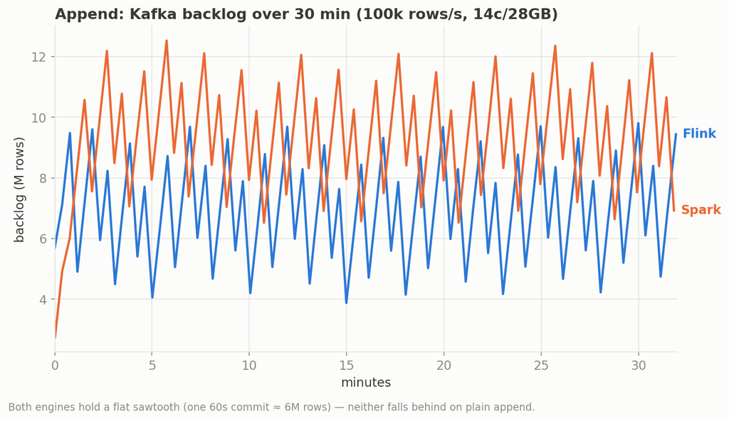

At 100k rows/s on 14 cores, **both engines keep up on plain append.** The backlog is a flat sawtooth — climb for 60 s, commit ~6M rows, drop — with a post-commit floor that doesn't grow. Good news for Spark: for straight ingestion, it holds the line.

But "keeping up" isn't free, and the price differs:

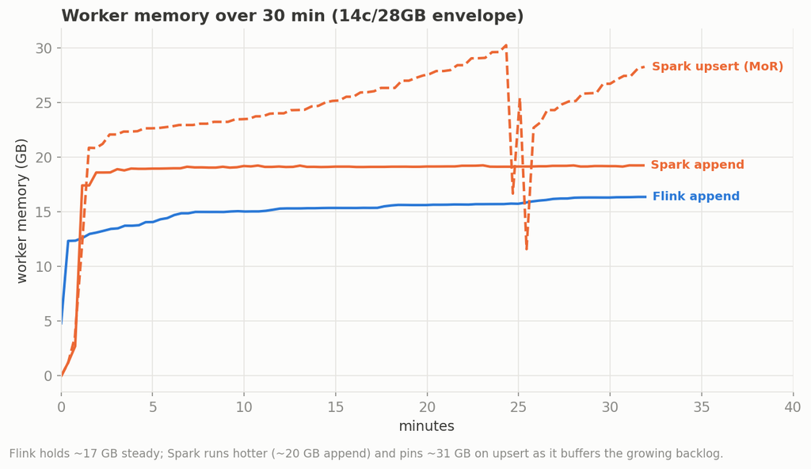

## Result 2 — Upsert: Flink holds; both Spark modes collapse

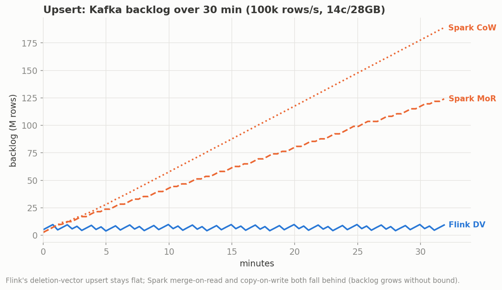

This is the chart that matters.

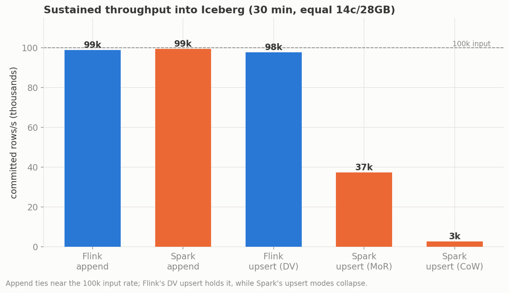

The throughput bars make the divergence blunt: append ties near the 100k line; Flink's upsert holds it; Spark's upsert modes fall off a cliff.

## Result 3 — Where the time goes: the write path

The bottleneck isn't the engine's record processing — it's the Iceberg **commit/write path**. Spark's own batch instrumentation shows exactly where each micro-batch spends its time:

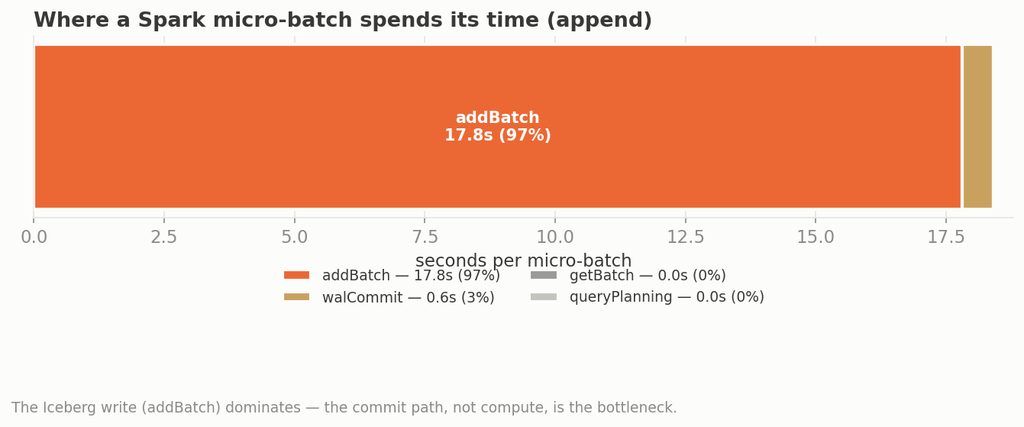

**~97% of every micro-batch is `addBatch`** — the Iceberg write and flush. The commit path is the wall. That's why the lever that *actually* moves throughput is the number of concurrent write streams (Iceberg bucket count), and it's why copy-on-write — which multiplies the write work by rewriting whole files — is hopeless for streaming.

[figure not shown]

Meanwhile Flink's checkpoints — the mechanism behind its commits — are trivial: ~1.1 s each, ~9 KB of state. There's no hidden cost hiding in Flink's numbers.

## Result 4 — File health

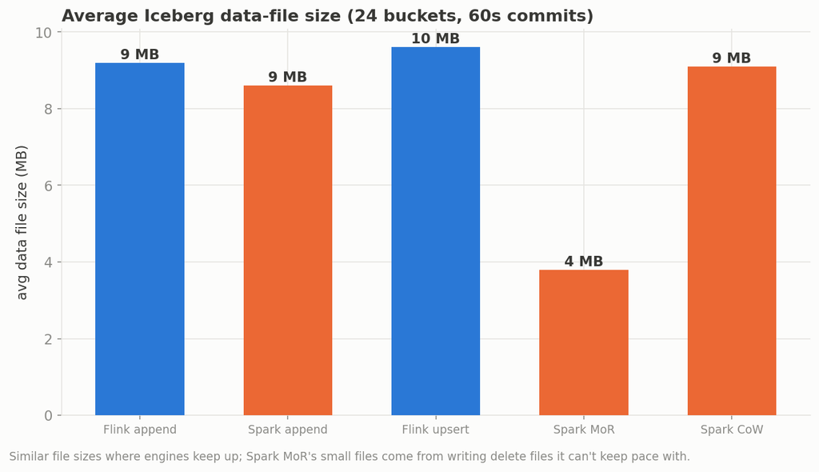

Where both engines keep up (append, Flink upsert) the files are comparable — ~9 MB average at 24 buckets and 60-second commits. Spark merge-on-read's smaller files are a *symptom* of falling behind: it's emitting delete files it can't keep pace with. (File size is a tunable tradeoff against throughput — more buckets = more parallel writers = higher throughput but smaller files. We picked 24 as the knee of that curve; the repo lets you sweep it.)

## Local mirrors the cloud

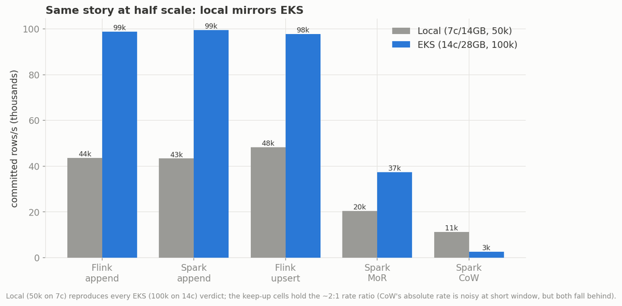

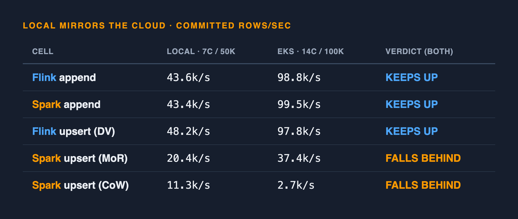

The comparison is scale-invariant: the same code, tuned the same way, tells the same story on a laptop and on a six-node cluster. That's the point of running both — you can reproduce the headline on your machine before spending a cent on EKS.

## Reproduce it

### Local (laptop, ~10 minutes, free)

```bash
git clone github.com/fmorillo7694/spark-flink-iceberg && cd spark-flink-iceberg
docker compose up -d                 # Kafka, MinIO, Iceberg REST, Flink, Spark
python -m venv .venv && .venv/bin/pip install -r bench/requirements.txt

# one cell:
RUN_SECONDS=300 bash bench/run_local_bench.sh flink append
# the full 5-cell matrix:
bash bench/run_local_matrix.sh
# tables + charts:
python bench/analyze_matrix.py results/local local_ "LOCAL"
python bench/make_charts.py
```

Flink UI → `http://localhost:8081`, Spark UI → `http://localhost:4040`.

### EKS (cloud, from an empty account)

The `eks/` directory is a standalone, numbered runbook. It creates a fresh VPC and cluster — nothing assumes pre-existing infrastructure.

```bash
cd eks
# 0. edit 00_profile.env: AWS_REGION, CLUSTER, your expected account id
source 00_profile.env

bash 01_create_cluster.sh     # eksctl: VPC + 6× m5.2xlarge, KMS, OIDC, IMDSv2
bash 02_install.sh            # S3 warehouse bucket, Glue DB, EBS CSI + gp3,
                              #   Strimzi Kafka, Flink + Spark operators, cert-manager
bash 02b_irsa.sh              # least-privilege IRSA: S3 + Glue + KMS; node-role S3
bash 03_build_push_images.sh  # build & push flink/spark/load images to ECR

# one 30-min cell:
WRITE=upsert PART=bucket RUN_SECONDS=1800 bash 04_run_benchmark.sh flink 12 10 10000
# or the full 5-cell matrix:
bash 05_run_matrix_30min.sh

bash 99_teardown.sh           # deletes everything (cluster ~$2.40/hr — don't skip)
```

Each run drops and recreates its table, resets the topic to a clean 12 partitions, starts the producer fleet *before* the engine (so Spark's first micro-batch always has data — Spark 4.1.2 NPEs on an empty first batch), samples backlog + CPU/mem every 15 s, and captures the Iceberg snapshot, checkpoint, and batch-timing metrics at teardown. The fairness contract — identical cores, memory, parallelism, partitions, buckets, and commit interval for both engines — is enforced in the job manifests and documented in `eks/PARITY.md`.

> **This path is tested, not just written.** I ran the whole sequence from a truly empty account — `eksctl` provisioning a brand-new VPC — and re-ran all five cells on that fresh cluster. The numbers matched the results above, and the exercise flushed out three real first-run bugs (an unrendered manifest placeholder, a missing PVC RBAC grant, a registry-env gap) that only surface on a clean cluster. They're fixed in the scripts here, so your first run is the one that works.

## Takeaways

None of this says Spark is a bad streaming engine. It says that *for this specific workload* — high-rate keyed ingestion into an Iceberg table — Flink's commit model fits the shape of the problem better, and the gap widens exactly where real ingestion pipelines live: upserts.

*(There's a whole other axis to this — what each engine's Iceberg connector can actually **do**: dynamic multi-table sinks, in-stream schema evolution, equality vs positional deletes. That's a feature comparison rather than a performance one, so it's a post of its own — coming next.)*

*All numbers regenerated from the repo. Found a way to make Spark keep up on upsert? Open an issue — the harness is built to be argued with.*